# Take Home Final Exam

For the take-home part of the MSDS 401 Final Exam, you are tasked with analyzing data on new daily covid-19 cases and deaths in European Union (EU) and European Economic Area (EEA) countries. A data file may be downloaded [here](https://www.ecdc.europa.eu/en/publications-data/data-daily-new-cases-covid-19-eueea-country), *or* you may use the provided **read.csv()** code in the ‘setup’ code chunk below to read the data directly from the web csv. Either approach is acceptable; the data should be the same.

Once you have defined a data frame with the daily case and death and country data, you are asked to: (1) perform an Exploratory Data Analysis (EDA), (2) perform some hypothesis testing, (3) perform some correlation testing, and (4) fit and describe a linear regression model. Each of these four (4) items is further explained below and “code chunks” have been created for you in which to add your R code, just as with the R and Data Analysis Assignments. You may add additional code chunks, as needed. You should make comments in the code chunks or add clarifying text between code chunks that you think further your work.

A data dictionary for the dataset is available [here](https://www.ecdc.europa.eu/sites/default/files/documents/Description-and-disclaimer_daily_reporting.pdf).

#### Definitions:

- “Incidence rate” is equal to new daily cases per 100K individuals. Country population estimates can be found in ‘popData2020.’ You will calculate a daily incidence rate in item (1), for each country, that we will explore further in items (2) and (3).
- “Fatality rate” is equal to new daily deaths per 100K individuals. Country population estimates can be found in ‘popData2020.’ You will calculate a daily fatality rate in item (1), for each country, that we will explore further in items (2) and (3).

#### 1. Descriptive Statistics

Perform an Exploratory Data Analysis (EDA). Your EDA is exactly that: yours. Your knit .html should include the visualizations and summary tables that you find valuable while exploring this dataset. **However**, at minimum, your EDA must include the following:

- Creation of a vector, ‘incidence_rate,’ equal to the daily new cases per 100K individuals, per country. Country populations are provided in ‘popData2020.’ This vector should be added to the ‘data’ data frame.
- Creation of a vector, ‘fatality_rate,’ equal to the new deaths per 100K individuals, per country. Country populations are provided in ‘popData2020.’ This vector should be added to the ‘data’ data frame.
- A visualization exploring new cases or incidence rates, per country, over time. You may choose a subset of countries, if you wish, but your visualization should include at least five (5) countries and include the entire time frame of the dataset.
- A visualization exploring new deaths or fatality rates, per country, over time. You may choose a subset of countries, if you wish, but your visualization should include at least five (5) countries.
- A table or visualization exploring some other aspect of the data. For example, you could explore case fatality rates per country; the number of deaths divided by the total number of cases. Note that to do this, you would want to like across the entire time of the dataset, looking at the total cases and deaths, per country.

```r
data <- data[(data$cases>=0) & (data$deaths>=0), ]
sum(is.na(data))
```

```
## [1] 3850
```

```r
data<-na.omit(data)
sum(is.na(data))
```

```
## [1] 0
```

```r
# Create vectors 'incidence_rate' and 'fatality_rate'
data$incidence_rate <- (data$cases/data$popData2020)*100000
data$fatality_rate <- (data$deaths/data$popData2020)*100000
```

```r
# Calculate the total number of cases by country
# and choose the top 5 cases countries
total_case_by_country <- aggregate(cases ~ countriesAndTerritories, data = data, FUN = sum,na.rm=TRUE)

sort_cases <- total_case_by_country[order(-total_case_by_country$cases), ]

top_5_countries <- head(sort_cases, 5)

print(top_5_countries)
```

```
##    countriesAndTerritories    cases
## 10                  France 36952159
## 11                 Germany 35287690
## 16                   Italy 23359251
## 29                   Spain 13564823
## 22             Netherlands  8494705
```

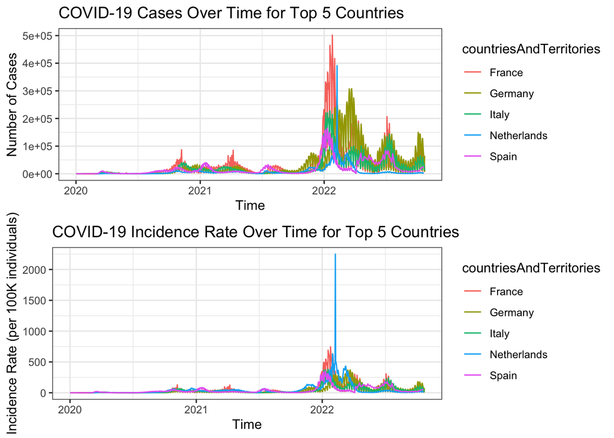

```r
# Create a subset for top 5 cases countries
selected_countries <- c("France", "Germany", "Italy", "Spain", "Netherlands")
subset_data<- data[data$countriesAndTerritories %in% selected_countries, ]

# Create graphs for cases and incidence rate over time by top 5 countries
case_p1 <- ggplot(data=subset_data, aes(x=dateRep, y=cases,
                          group=countriesAndTerritories, color=countriesAndTerritories)) +
  ggtitle('COVID-19 Cases Over Time for Top 5 Countries') +
  xlab('Time') +
  ylab('Number of Cases') +
  geom_line(size=0.5) +
  theme_bw()

incidence_p2 <- ggplot(data=subset_data, aes(x=dateRep, y=incidence_rate,
                          group=countriesAndTerritories, color=countriesAndTerritories)) +
  ggtitle('COVID-19 Incidence Rate Over Time for Top 5 Countries') +
  xlab('Time') +
  ylab('Incidence Rate (per 100K individuals)') +
  geom_line(size=0.5) +
  theme_bw()

grid.arrange(case_p1, incidence_p2, nrow=2)
```

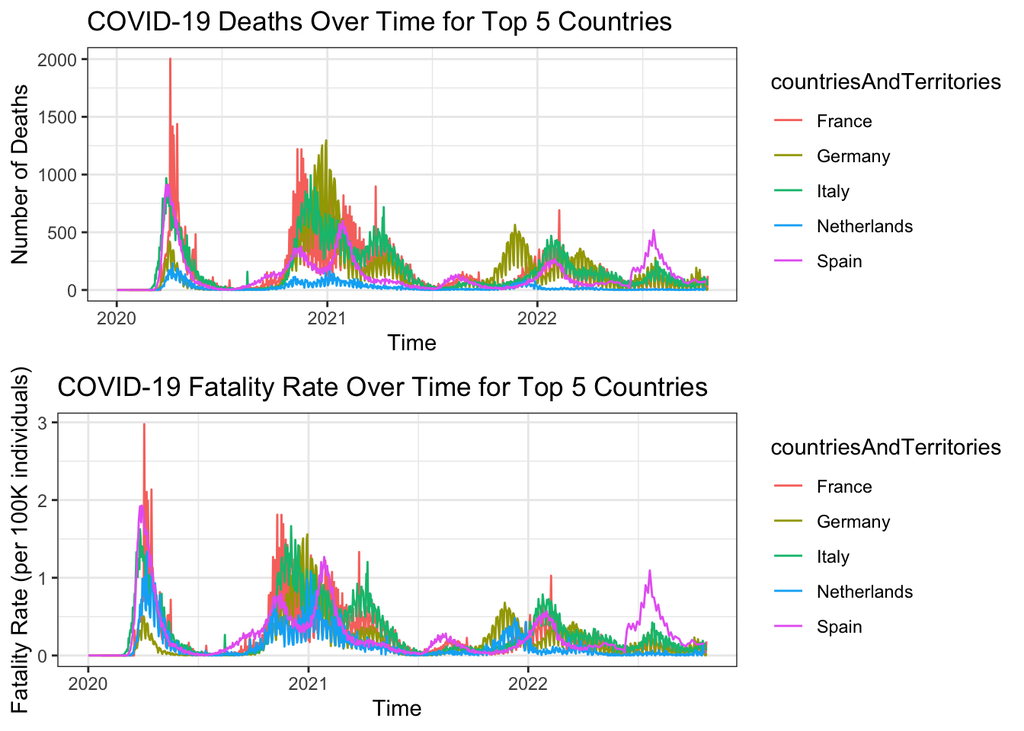

```r
# Create graphs for deaths and fatality rate over time by top 5 countries
case_p1 <- ggplot(data=subset_data, aes(x=dateRep, y=deaths,
                          group=countriesAndTerritories, color=countriesAndTerritories)) +
  ggtitle('COVID-19 Deaths Over Time for Top 5 Countries') +
  xlab('Time') +
  ylab('Number of Deaths') +
  geom_line(size=0.5) +
  theme_bw()

incidence_p2 <- ggplot(data=subset_data, aes(x=dateRep, y=fatality_rate,
                          group=countriesAndTerritories, color=countriesAndTerritories)) +
  ggtitle('COVID-19 Fatality Rate Over Time for Top 5 Countries') +
  xlab('Time') +
  ylab('Fatality Rate (per 100K individuals)') +
  geom_line(size=0.5) +
  theme_bw()

grid.arrange(case_p1, incidence_p2, nrow=2)
```

```r
# Basic information about the dataset
summary(data)
```

```
##     dateRep                day            month             year
##  Min.   :2020-01-01   Min.   : 1.00   Min.   : 1.000   Min.   :2020
##  1st Qu.:2020-10-16   1st Qu.: 8.00   1st Qu.: 4.000   1st Qu.:2020
##  Median :2021-06-16   Median :16.00   Median : 6.000   Median :2021
##  Mean   :2021-06-16   Mean   :15.69   Mean   : 6.441   Mean   :2021
##  3rd Qu.:2022-02-13   3rd Qu.:23.00   3rd Qu.: 9.000   3rd Qu.:2022
##  Max.   :2022-10-26   Max.   :31.00   Max.   :12.000   Max.   :2022
##
##      cases            deaths         countriesAndTerritories     geoId
##  Min.   :     0   Min.   :    0.00   Finland  : 1024         FI     : 1024
##  1st Qu.:   119   1st Qu.:    0.00   Czechia  : 1002         CZ     : 1002
##  Median :   724   Median :    5.00   France   : 1000         FR     : 1000
##  Mean   :  6168   Mean   :   40.95   Lithuania:  996         LT     :  996
##  3rd Qu.:  3565   3rd Qu.:   31.00   Germany  :  992         DE     :  992
##  Max.   :501635   Max.   :13743.00   Sweden   :  982         SE     :  982
##                                      (Other)  :22317         (Other):22317
##  countryterritoryCode  popData2020       incidence_rate     fatality_rate
##  FIN    : 1024        Min.   :   38747   Min.   :   0.000   Min.   :  0.00000
##  CZE    : 1002        1st Qu.: 2095861   1st Qu.:   2.581   1st Qu.:  0.00000
##  FRA    : 1000        Median : 6951482   Median :  13.219   Median :  0.08189
##  LTU    :  996        Mean   :15444228   Mean   :  42.208   Mean   :  0.27030
##  DEU    :  992        3rd Qu.:11522440   3rd Qu.:  41.011   3rd Qu.:  0.32111
##  SWE    :  982        Max.   :83166711   Max.   :3785.420   Max.   :128.21679
##  (Other):22317
```

```r
table<-aggregate(cbind(cases, deaths)~countriesAndTerritories,data = data, sum)
table$case_fatality_rate <- (table$deaths/table$cases)*100
table
```

```
##    countriesAndTerritories    cases deaths case_fatality_rate
## 1                  Austria  5402162  20899          0.3868636
## 2                  Belgium  4597870  32883          0.7151790
## 3                 Bulgaria  1271735  37790          2.9715310
## 4                  Croatia  1244692  17085          1.3726287
## 5                   Cyprus   599500   1188          0.1981651
## 6                  Czechia  4152997  41524          0.9998562
## 7                  Denmark  3221572   7116          0.2208860
## 8                  Estonia   592700   2729          0.4604353
## 9                  Finland  1335318   6407          0.4798108
## 10                  France 36952159 156518          0.4235693
## 11                 Germany 35287690 152753          0.4328790
## 12                  Greece  5138059  33574          0.6534374
## 13                 Hungary  2141513  47938          2.2385108
## 14                 Iceland   176725    213          0.1205262
```

[output cut: 16 more lines]

#### 2. Inferential Statistics

Select two (2) countries of your choosing and compare their incidence or fatality rates using hypothesis testing. At minimum, your work should include the following:

- Visualization(s) comparing the daily incidence or fatality rates of the selected countries,
- A statement of the null hypothesis.
- A short justification of the statistical test selected.
  - Why is the test you selected an appropriate one for the comparison we’re making?
- A brief discussion of any distributional assumptions of that test.
  - Does the statistical test we selected require assumptions about our data?
  - If so, does our data satisfy those assumptions?
- Your selected alpha.
- The test function output; i.e. the R output.
- The relevant confidence interval, if not returned by the R test output.
- A concluding statement on the outcome of the statistical test.
  - i.e. Based on our selected alpha, do we reject or fail to reject our null hypothesis?

#### Null & Alterntative Hypothesis Statement:

mu1 is the mean COVID-19 incidence rates per 100K people in France mu2 is the mean COVID-19 incidence rates per 100K people in Germany

H0: mu1 - mu2 = 0 H0: The difference between the mean COVID-19 incidence rates per 100K people in France and Germany is the same. Ha: mu1 - mu2 != 0 Ha: The difference between the mean COVID-19 incidence rates per 100K people in France and Germany is not the same.

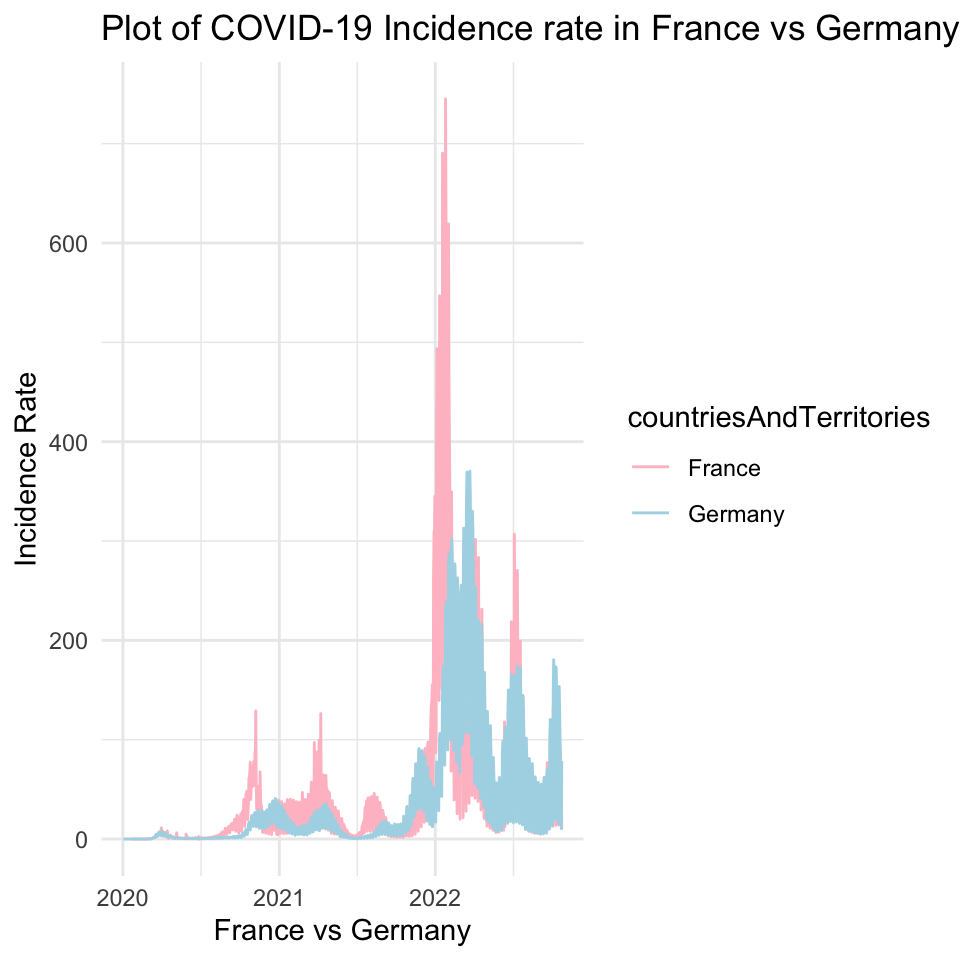

```r
data2 <- subset(data, countriesAndTerritories == "France" |
                  countriesAndTerritories == "Germany")

ggplot(data2, aes(x=dateRep, y=incidence_rate,
                  group=countriesAndTerritories, color=countriesAndTerritories)) +
  ggtitle("Plot of COVID-19 Incidence rate in France vs Germany") +
  scale_colour_manual(values=c("pink","lightblue")) +
  xlab("France vs Germany") +
  ylab("Incidence Rate") +
  geom_line(size=0.5) +
  theme_minimal()
```

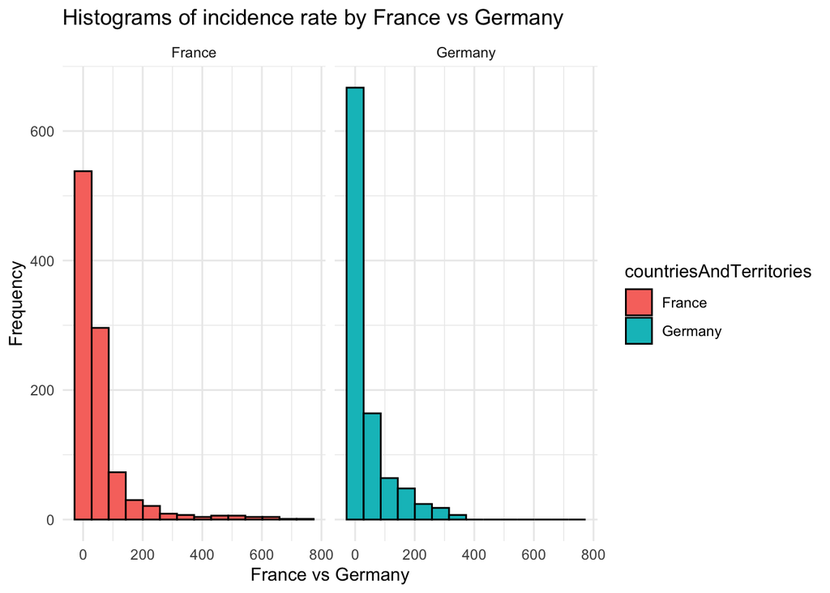

```r
ggplot(data2, aes(x=incidence_rate, fill=countriesAndTerritories)) +
  facet_grid(. ~ countriesAndTerritories, space="free") +
  geom_histogram(bins=14, color="black") +
  xlab("France vs Germany") +
  ylab("Frequency") +
  ggtitle("Histograms of incidence rate by France vs Germany") +
  theme(legend.position="topright") +
  theme_minimal()
```

```r
#checking whether two countries are normally distributed
France <- subset(data, countriesAndTerritories == "France")
Germany <- subset(data, countriesAndTerritories == "Germany")

skewness_value_F <- rockchalk::skewness(France$incidence_rate)
kurtosis_value_F <- rockchalk::kurtosis(France$incidence_rate) + 3
cat("Skewness for France incidence rate:", skewness_value_F, "\n")
```

```
## Skewness for France incidence rate: 3.656043
```

```r
cat("Kurtosis for France incidence rate:", kurtosis_value_F, "\n")
```

```
## Kurtosis for France incidence rate: 18.57803
```

```r
skewness_value_G <- rockchalk::skewness(Germany$incidence_rate)
kurtosis_value_G <- rockchalk::kurtosis(Germany$incidence_rate) + 3
cat("Skewness for Germany incidence rate:", skewness_value_G, "\n")
```

```
## Skewness for Germany incidence rate: 2.369289
```

```r
cat("Kurtosis for Germany incidence rate:", kurtosis_value_G, "\n")
```

```
## Kurtosis for Germany incidence rate: 8.570674
```

#### Test to move forward with

We want to use an independent Two-Sample t-Test to compare the mean incidence rates of the two countries as the means of the incidence rate of France and Germany are independent. However, one of the key assumptions of a T-test is that the two samples have to be drawn from two normally distributed populations.Based on the histogram as well as the skewness and kurtosis values for the incidence rates of France and Germany, it appears that both countries are highly skewed and has high kurtosis, which suggests that the data distribution is not normal and has a heavy, long tail on one side. Therefore, the typical t-test (which assumes normal distribution) is not proper to use in this place. Thus, we will use not only a standard independent two sample T-test and assume normal distribution, but also a log transformation and a non-parametric test that does not assume normal distribution, such as the Wilcoxon rank-sum test. However, this Wilcoxon rank-sum test assumes that two groups’ distributions are roughly similar in shape. Therefore, I will first check France and Germany’s incidence rate distribution shapes, using boxplots and density plots.

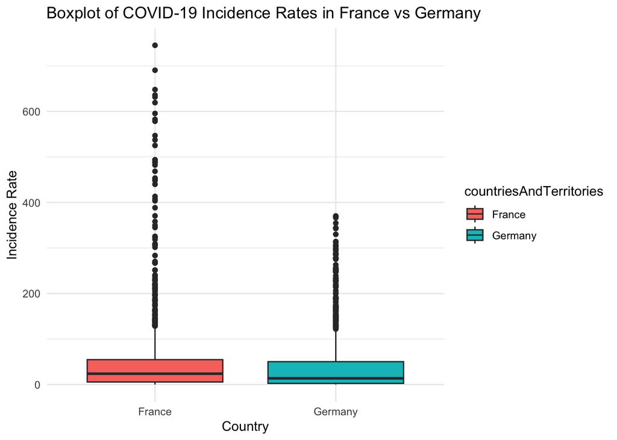

```r
# Box plots for a visual check of distribution shapes
ggplot(data2, aes(x = countriesAndTerritories, y = incidence_rate, fill = countriesAndTerritories)) +
  geom_boxplot() +
  ggtitle("Boxplot of COVID-19 Incidence Rates in France vs Germany") +
  xlab("Country") +
  ylab("Incidence Rate") +
  theme_minimal()
```

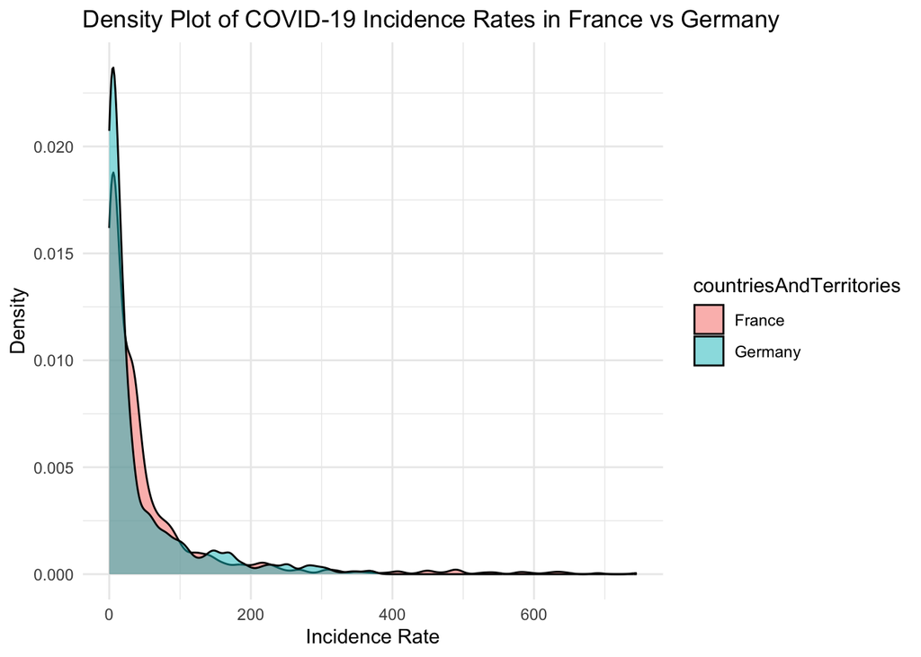

```r
# Density plots for a visual check of distribution shapes
ggplot(data2, aes(x = incidence_rate, fill = countriesAndTerritories)) +
  geom_density(alpha = 0.5) +
  ggtitle("Density Plot of COVID-19 Incidence Rates in France vs Germany") +
  xlab("Incidence Rate") +
  ylab("Density") +
  theme_minimal()
```

The incidence rate distribution shapes for France and Germany are similar by looking at their boxplots and density plots. Thus, we can use the Wilcoxon rank-sum test.

First, we run a standard T-test assuming normal distribution.

```r
t.test(France$incidence_rate, Germany$incidence_rate)
```

```
##
##  Welch Two Sample t-test
##
## data:  France$incidence_rate and Germany$incidence_rate
## t = 3.2089, df = 1784.6, p-value = 0.001356
## alternative hypothesis: true difference in means is not equal to 0
## 95 percent confidence interval:
##   4.711288 19.524500
## sample estimates:
## mean of x mean of y
##  54.89014  42.77224
```

We then will use log transformation.

```r
log10_inc <- log10(data2$incidence_rate)

data2$log10_incidence_rate <- log10_inc
```

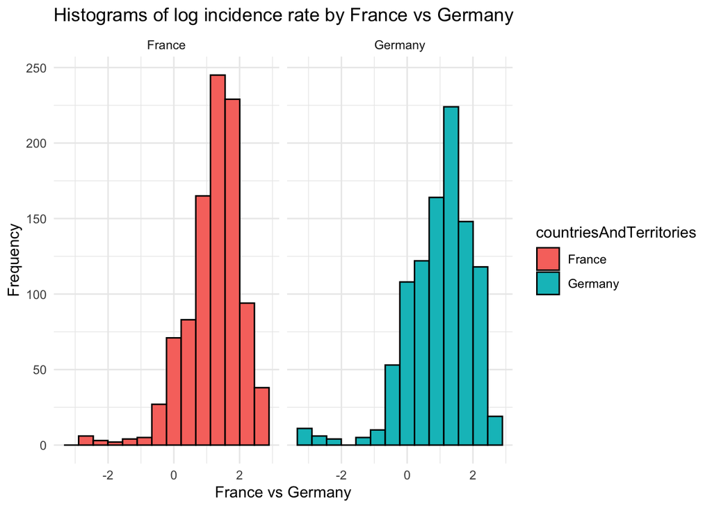

```r
ggplot(data2, aes(x=log10_incidence_rate, fill=countriesAndTerritories)) +
  facet_grid(. ~ countriesAndTerritories, space="free") +
  geom_histogram(bins=14, color="black") +
  xlab("France vs Germany") +
  ylab("Frequency") +
  ggtitle("Histograms of log incidence rate by France vs Germany") +
  theme(legend.position="topright") +
  theme_minimal()
```

```r
France_2 <- subset(data2, countriesAndTerritories == "France")
Germany_2 <- subset(data2, countriesAndTerritories == "Germany")


France_2 <- France_2[!is.infinite(France_2$log10_incidence_rate), ]

France_2 <- France_2[!apply(France_2, 1, function(x) any(is.infinite(x))), ]
skewness_value_log_F <- rockchalk::skewness(France_2$log10_incidence_rate)
kurtosis_value_log_F <- rockchalk::kurtosis(France_2$log10_incidence_rate) + 3
cat("Skewness for France incidence rate:", skewness_value_log_F, "\n")
```

```
## Skewness for France incidence rate: -1.192788
```

```r
cat("Kurtosis for France incidence rate:", kurtosis_value_log_F, "\n")
```

```
## Kurtosis for France incidence rate: 6.010383
```

```r
skewness_value_log_G <- rockchalk::skewness(Germany_2$log10_incidence_rate)
kurtosis_value_log_G <- rockchalk::kurtosis(Germany_2$log10_incidence_rate) + 3
cat("Skewness for Germany incidence rate:", skewness_value_log_G, "\n")
```

```
## Skewness for Germany incidence rate: -1.179382
```

```r
cat("Kurtosis for Germany incidence rate:", kurtosis_value_log_G, "\n")
```

```
## Kurtosis for Germany incidence rate: 5.562636
```

After log transformation, the samples are more normally distributed looking at the histograms as well as the skewness and kurtosis values. Thus, we can do a T-test after log transformation.

```r
log_france <- log10(France$incidence_rate)
log_germany <- log10(Germany$incidence_rate)

France$log10_incidence_rate <- log_france
Germany$log10_incidence_rate <- log_germany

France$log10_incidence_rate[France$log10_incidence_rate == Inf | France$log10_incidence_rate == -Inf] <- 0
Germany$log10_incidence_rate[Germany$log10_incidence_rate == Inf | Germany$log10_incidence_rate == -Inf] <- 0

t.test(France$log10_incidence_rate, Germany$log10_incidence_rate)
```

```
##
##  Welch Two Sample t-test
##
## data:  France$log10_incidence_rate and Germany$log10_incidence_rate
## t = 4.8681, df = 1950, p-value = 1.218e-06
## alternative hypothesis: true difference in means is not equal to 0
## 95 percent confidence interval:
##  0.1199236 0.2817398
## sample estimates:
## mean of x mean of y
## 1.1891016 0.9882699
```

We conduct a Wilcoxon rank sum test on the data samples.

```r
alpha<-0.05
test_result <- wilcox.test(incidence_rate ~ countriesAndTerritories, data = data2)
test_result
```

```
##
##  Wilcoxon rank sum test with continuity correction
##
## data:  incidence_rate by countriesAndTerritories
## W = 551524, p-value = 1.52e-05
## alternative hypothesis: true location shift is not equal to 0
```

```r
ci <- quantile(
    test_result$statistic +
    rnorm(10000, mean = 0, sd = sqrt(test_result$statistic)),
    probs = c(0.025, 0.975))

print(ci)
```

```
##     2.5%    97.5%
## 550043.4 553013.7
```

#### Final Conclusions of Hypothesis Test

The three hypothesis tests, including a normal T-test, T-test after log transformation, and a Wilcoxon rank-sum test, showed that the p-values are 0.001356, 1.218e-06, 1.52e-05 respectively. All of the p-values are smaller than alpha 0.05, so we can confidently conclude to reject the null hypothesis. Thus, we are 95% confident that there is a difference in mean COVID-19 incidence rates per 100K people between France and Germany.

#### 3. Correlation

Considering all countries, explore the relationship between incidence rates and fatality rates. At minimum, your work should include the following:

- Visualization(s) showing the distributions of daily incidence and fatality rates, regardless of country. Please note that both country and date should be disregarded here.
- A short statement identifying the most appropriate correlation coefficient.
  - For the correlation we’re interested in, which correlation coefficient is most appropriate?
  - Why do you find the correlation coefficient selected to be the most appropriate?
- The calculated correlation coefficient or coefficient test output; e.g. *cor()* or *cor.test()*.

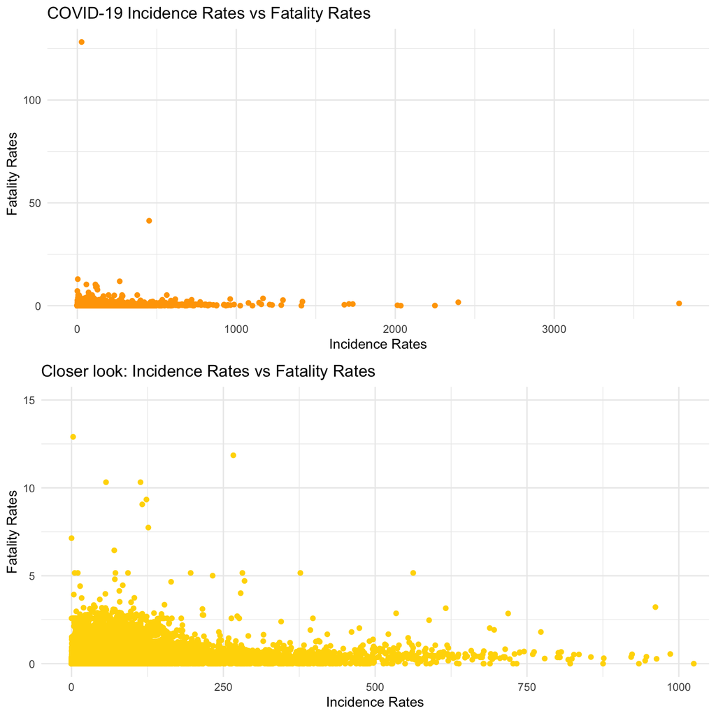

```r
p1 <- ggplot(data, aes(x=incidence_rate, y=fatality_rate)) +
      geom_point(color="orange") +
      labs(x="Incidence Rates", y="Fatality Rates",
           title="COVID-19 Incidence Rates vs Fatality Rates") +
      theme_minimal()

p2 <- ggplot(data, aes(x=incidence_rate, y=fatality_rate)) +
      geom_point(color="gold") +
      labs(x="Incidence Rates", y="Fatality Rates",
           title="Closer look: Incidence Rates vs Fatality Rates") +
      coord_cartesian(xlim=c(0, 1000), ylim=c(0, 15)) +
      theme_minimal()

grid.arrange(p1, p2, nrow = 2)
```

```r
library(kableExtra)
library(tidyr)
correl <- cor(data[10:12])
correl %>%
  kbl() %>%
  kable_styling()
```

|  | popData2020 | incidence_rate | fatality_rate |
| --- | --- | --- | --- |
| popData2020 | 1.0000000 | -0.0176028 | -0.0039968 |
| incidence_rate | -0.0176028 | 1.0000000 | 0.1129893 |
| fatality_rate | -0.0039968 | 0.1129893 | 1.0000000 |

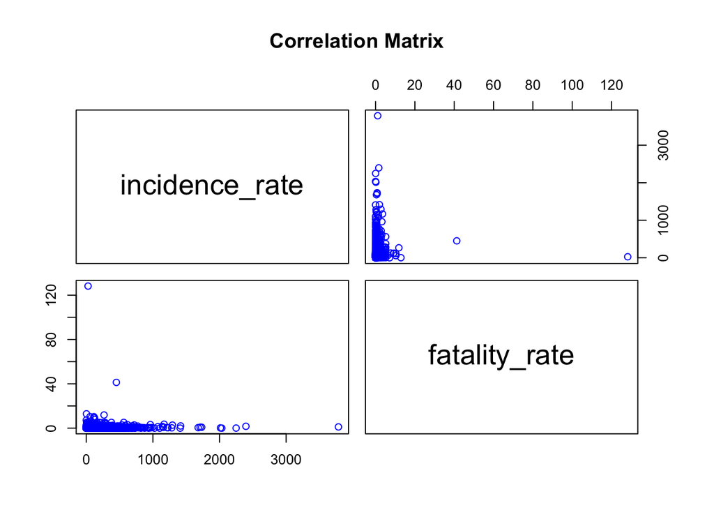

```r
pairs(data[11:12], col = "blue", main = "Correlation Matrix")
```

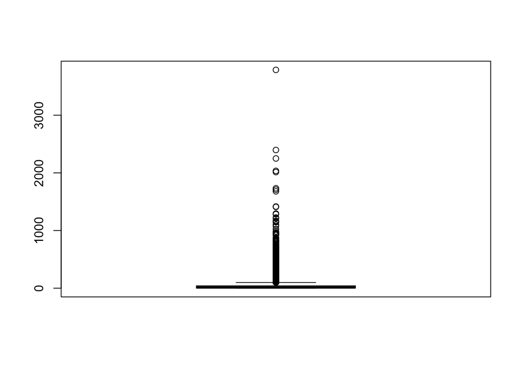

```r
boxplot(data$incidence_rate)
```

```r
boxplot.stats(data$incidence_rate, coef=3)$out
```

```
##    [1]  160.7111  207.8179  161.6773  174.8106  171.7885  208.1886  159.5315
##    [8]  172.0693  168.4742  168.0473  182.0232  233.4328  170.0134  211.0310
##   [15]  247.5659  291.1337  380.1231  291.2348  233.8597  284.9547  369.5513
##   [22]  415.2088  458.9227  610.9831  413.6247  349.0369  419.3881  471.4605
##   [29]  567.3591  578.9757  713.4990  449.3957  384.4821  419.9049  487.9304
##   [36]  553.7316  560.6858  572.5720  382.2801  297.4139  309.2215  353.3398
##   [43]  357.4629  355.2497  458.6867  306.6263  238.0727  247.7120  281.0451
##   [50]  334.0612  319.9955  395.4920  265.5188  239.6455  244.3191  288.7183
##   [57]  342.2625  346.0485  434.6110  296.8634  269.3386  279.9328  333.6455
##   [64]  373.0004  394.3798  450.9012  326.1857  290.9427  337.5664  375.3821
##   [71]  414.9841  380.3478  496.4238  312.8839  295.6613  327.7810  378.2357
##   [78]  425.6907  401.2554  428.3533  299.5260  282.0899  262.0249  299.4698
##   [85]  332.5445  282.3370  315.5241  205.4249  180.7649  166.4295  190.9884
##   [92]  189.9099  188.3932  185.1464  162.0817  162.8345  158.1047  157.7564
##   [99]  167.0025  168.5192  184.7195  156.4686  157.2323  168.7663  238.0572
```

[output cut: 226 more lines]

```r
summary(data$incidence_rate)
```

```
##     Min.  1st Qu.   Median     Mean  3rd Qu.     Max.
##    0.000    2.581   13.219   42.208   41.011 3785.420
```

```r
summary(data$fatality_rate)
```

```
##      Min.   1st Qu.    Median      Mean   3rd Qu.      Max.
##   0.00000   0.00000   0.08189   0.27030   0.32111 128.21679
```

```r
tempi<- data[(data$incidence_rate<=50) & (data$fatality_rate<=0.32), ]
```

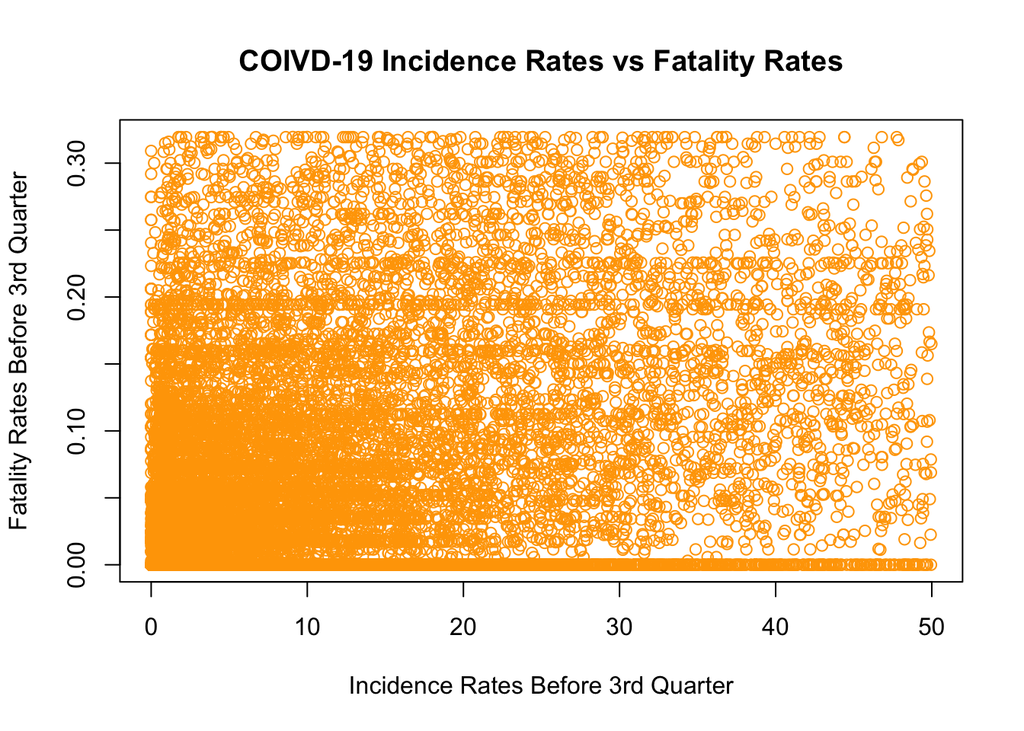

```r
plot(x=tempi$incidence_rate,y=tempi$fatality_rate, xlab = "Incidence Rates Before 3rd Quarter",
     ylab ="Fatality Rates Before 3rd Quarter", main = "COIVD-19 Incidence Rates vs Fatality Rates",
     col ="orange")
```

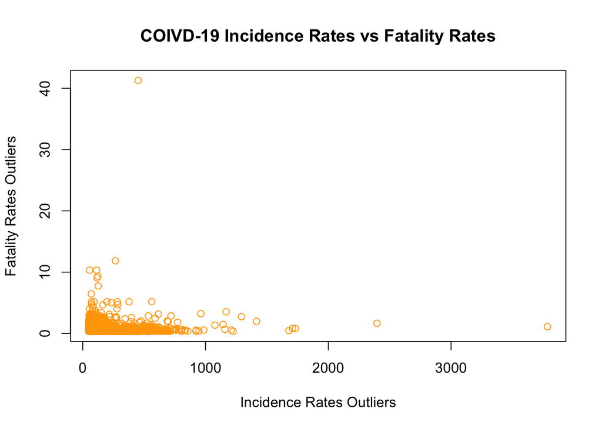

```r
tempb<- data[(data$incidence_rate>50) & (data$fatality_rate>0.32), ]
plot(x=tempb$incidence_rate,y=tempb$fatality_rate, xlab = "Incidence Rates Outliers",
     ylab ="Fatality Rates Outliers", main = "COIVD-19 Incidence Rates vs Fatality Rates",
     col ="orange")
```

#### Chosen Correlation Coefficient

```r
cor(tempi$incidence_rate, tempi$fatality_rate, use="complete.obs", method = "pearson")
```

```
## [1] 0.3962233
```

```r
cor(tempb$incidence_rate, tempb$fatality_rate, use="complete.obs", method = "pearson")
```

```
## [1] -0.04637824
```

#### 4. Regression

Here, we will fit a model on data from twenty (20) countries considering total new cases as a function of population, population density and gross domestic product (GDP) per capita. Note that the GDP per capita is given in “purchasing power standard,” which considers the costs of goods and services in a country relative to incomes in that country; i.e. we will consider this as appropriately standardized.

Code is given below defining a new data frame, ‘model_df,’ which provides the total area and standardized GDP per capita for the twenty (20) countries for our model fit. You are responsible for creating a vector of the total new cases across the time frame of the dataset, for each of those countries, and adding that vector to our ’model_df” data frame.

```r
# The code below creates a new data frame, 'model_df,' that includes the area,
# GDP per capita, population and population density for the twenty (20)
# countries of interest. All you should need to do is execute this code, as is.

# You do not need to add code in this chunk. You will need to add code in the
# 'regression_b,' 'regression_c' and 'regression_d' code chunks.

twenty_countries <- c("Austria", "Belgium", "Bulgaria", "Cyprus", "Denmark",
                      "Finland", "France", "Germany", "Hungary", "Ireland",
                      "Latvia", "Lithuania", "Malta", "Norway", "Poland",
                      "Portugal", "Romania", "Slovakia", "Spain", "Sweden")

sq_km <- c(83858, 30510, 110994, 9251, 44493, 338145, 551695, 357386, 93030,
           70273, 64589, 65300, 316, 385178, 312685, 88416, 238397, 49036,
           498511, 450295)

gdp_pps <- c(128, 118, 51, 91, 129, 111, 104, 123, 71, 190, 69, 81, 100, 142,
             71, 78, 65, 71, 91, 120)

model_df <- data %>%
  select(c(countriesAndTerritories, popData2020)) %>%
  filter(countriesAndTerritories %in% twenty_countries) %>%
  distinct(countriesAndTerritories, .keep_all = TRUE) %>%
  add_column(sq_km, gdp_pps) %>%
  mutate(pop_dens = popData2020 / sq_km) %>%
  rename(country = countriesAndTerritories, pop = popData2020)
```

Next, we need to add one (1) more column to our ‘model_df’ data frame. Specifically, one that has the total number of new cases for each of the twenty (20) countries. We calculate the total number of new cases by summing all the daily new cases, for each country, across all the days in the dataset.

```r
### The following code will be removed for students to complete the work themselves.

total_cases <- data %>%
  select(c(countriesAndTerritories, cases)) %>%
  group_by(countriesAndTerritories) %>%
  dplyr::summarize(total_cases = sum(cases, na.rm = TRUE)) %>%
  filter(countriesAndTerritories %in% twenty_countries) %>%
  select(total_cases)

model_df <- model_df %>%
  add_column(total_cases)
```

Now, we will fit our model using the data in ‘model_df.’ We are interested in explaining total cases (response) as a function of population (explanatory), population density (explanatory), and GDP (explanatory).

At minimum, your modeling work should including the following:

- A description - either narrative or using R output - of your ‘model_df’ data frame.
  - Consider: what data types are present? What do our rows and columns represent?
- The *lm()* *summary()* output of your fitted model. As we did in the second Data Analysis Assignment, you can pass your fitted model object - i.e. the output of **lm()** - to *summary()* and get additional details, including R^2, on your model fit.
- A short statement on the fit of the model.
  - Which, if any, of our coefficients are statistically significant?
  - What is the R^2 of our model?
  - Should we consider a reduced model; i.e. one with fewer parameters?

```r
summary(model_df)
```

```
##      country        pop               sq_km           gdp_pps
##  Austria : 1   Min.   :  514564   Min.   :   316   Min.   : 51.0
##  Belgium : 1   1st Qu.: 5266795   1st Qu.: 60701   1st Qu.: 71.0
##  Bulgaria: 1   Median : 7926273   Median : 90723   Median : 95.5
##  Cyprus  : 1   Mean   :17305840   Mean   :192118   Mean   :100.2
##  Denmark : 1   3rd Qu.:13474040   3rd Qu.:342955   3rd Qu.:120.8
##  Finland : 1   Max.   :83166711   Max.   :551695   Max.   :190.0
##  (Other) :14
##     pop_dens        total_cases
##  Min.   :  13.94   Min.   :  115285
##  1st Qu.:  57.67   1st Qu.: 1319422
##  Median : 100.50   Median : 2570210
##  Mean   : 179.14   Mean   : 6496297
##  3rd Qu.: 121.55   3rd Qu.: 5430242
##  Max.   :1628.37   Max.   :36952159
##
```

```r
library(MASS)
rm<-lm(total_cases~pop+pop_dens+gdp_pps, data=model_df)
summary(rm)
```

```
##
## Call:
## lm(formula = total_cases ~ pop + pop_dens + gdp_pps, data = model_df)
##
## Residuals:
##      Min       1Q   Median       3Q      Max
## -8290586 -1092896   -81818  1657083  8955212
##
## Coefficients:
##               Estimate Std. Error t value Pr(>|t|)
## (Intercept) -3.875e+06  2.787e+06  -1.390    0.183
## pop          4.285e-01  3.676e-02  11.658 3.13e-09 ***
## pop_dens     6.502e+02  2.432e+03   0.267    0.793
## gdp_pps      2.834e+04  2.559e+04   1.108    0.284
## ---
## Signif. codes:  0 '***' 0.001 '**' 0.01 '*' 0.05 '.' 0.1 ' ' 1
##
## Residual standard error: 3706000 on 16 degrees of freedom
## Multiple R-squared:  0.8963, Adjusted R-squared:  0.8769
## F-statistic:  46.1 on 3 and 16 DF,  p-value: 4.251e-08
```

```r
stepAIC(rm)
```

```
## Start:  AIC=608.56
## total_cases ~ pop + pop_dens + gdp_pps
##
##            Df  Sum of Sq        RSS    AIC
## - pop_dens  1 9.8181e+11 2.2077e+14 606.65
## - gdp_pps   1 1.6850e+13 2.3664e+14 608.04
## <none>                   2.1979e+14 608.56
## - pop       1 1.8668e+15 2.0866e+15 651.57
##
## Step:  AIC=606.65
## total_cases ~ pop + gdp_pps
##
##           Df  Sum of Sq        RSS    AIC
## - gdp_pps  1 1.7043e+13 2.3781e+14 606.14
## <none>                  2.2077e+14 606.65
## - pop      1 1.8723e+15 2.0931e+15 649.63
##
## Step:  AIC=606.14
## total_cases ~ pop
##
##        Df  Sum of Sq        RSS    AIC
## <none>               2.3781e+14 606.14
## - pop   1 1.8818e+15 2.1196e+15 647.89
```

```
##
## Call:
## lm(formula = total_cases ~ pop, data = model_df)
##
## Coefficients:
## (Intercept)          pop
##  -9.216e+05    4.286e-01
```

#### Conclusion from model result

For the initial model result, we can get the p-value for population is 3.13e-09. This suggests that as the population of a country increases the total number of new COVID-19 cases tends to increase correspondingly. The p-value for population density is 0.79 and p-value for gdp is 0.284. Applying the stepwise regression method (stepAIC), we found that a model with only the population variable yielded the lowest AIC, suggesting that it is the most parsimonious model. This simplification aligns with the lack of statistical significance found for population density and gdp. The adjusted r-squared of initial model is 0.8769, suggesting that the model has a good fit and 87.69% variation occurred in the new cases can be explained by this model.

## Check with the smaller model

```r
# New model without GDP and population density
rm2 <- lm(total_cases~pop, data=model_df)
rm2
```

```
##
## Call:
## lm(formula = total_cases ~ pop, data = model_df)
##
## Coefficients:
## (Intercept)          pop
##  -9.216e+05    4.286e-01
```

```r
summary(rm2)
```

```
##
## Call:
## lm(formula = total_cases ~ pop, data = model_df)
##
## Residuals:
##      Min       1Q   Median       3Q      Max
## -9159053  -814808   570800  1123412  9017900
##
## Coefficients:
##               Estimate Std. Error t value Pr(>|t|)
## (Intercept) -9.216e+05  1.023e+06  -0.901     0.38
## pop          4.286e-01  3.592e-02  11.935 5.51e-10 ***
## ---
## Signif. codes:  0 '***' 0.001 '**' 0.01 '*' 0.05 '.' 0.1 ' ' 1
##
## Residual standard error: 3635000 on 18 degrees of freedom
## Multiple R-squared:  0.8878, Adjusted R-squared:  0.8816
## F-statistic: 142.4 on 1 and 18 DF,  p-value: 5.51e-10
```

In the smaller model, the independent variable `pop` is statistical significant, since its p-value is 5.51e-10. Also, the adjusted R-squared of the smaller model is 0.8816, which performs a little bit better than the initial model. This implies that about 88.16% of the variation in total COVID-19 cases across the countries can be explained by population size alone. It suggests a strong model fit, indicating that population is a critical factor in explaining the variation in COVID-19 case numbers among these countries.

## EDA for the identified predictors

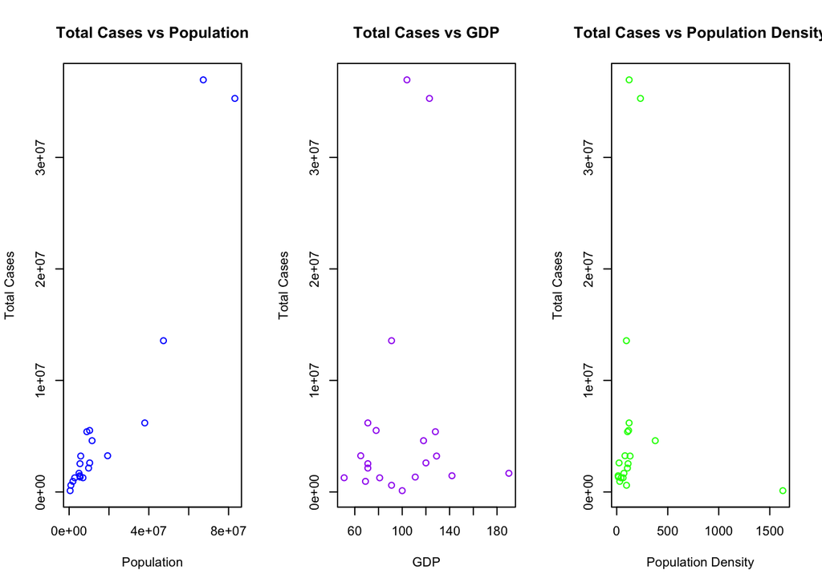

```r
par(mfrow = c(1,3))
plot(model_df$pop, model_df$total_cases, xlab = "Population", ylab = "Total Cases", main = "Total Cases vs Population",col = "blue")
plot(model_df$gdp_pps,model_df$total_cases, xlab = "GDP", ylab = "Total Cases", main = "Total Cases vs GDP",col = "purple")
plot(model_df$pop_dens,model_df$total_cases, xlab = "Population Density", ylab = "Total Cases", main = "Total Cases vs Population Density",col = "green")
```

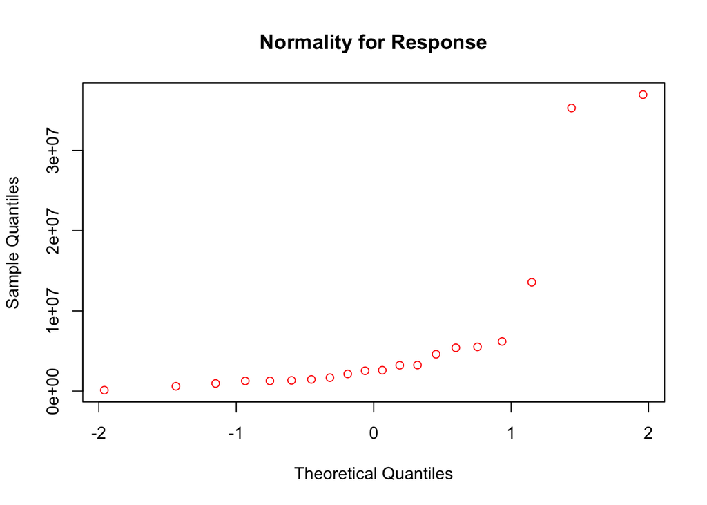

```r
par(mfrow = c(1,1))
qqnorm(model_df$total_cases, main = "Normality for Response", col = "red")
```

## Reviewing Residuals

```r
r <- residuals(rm)
par(mfrow = c())
```

```
## named list()
```

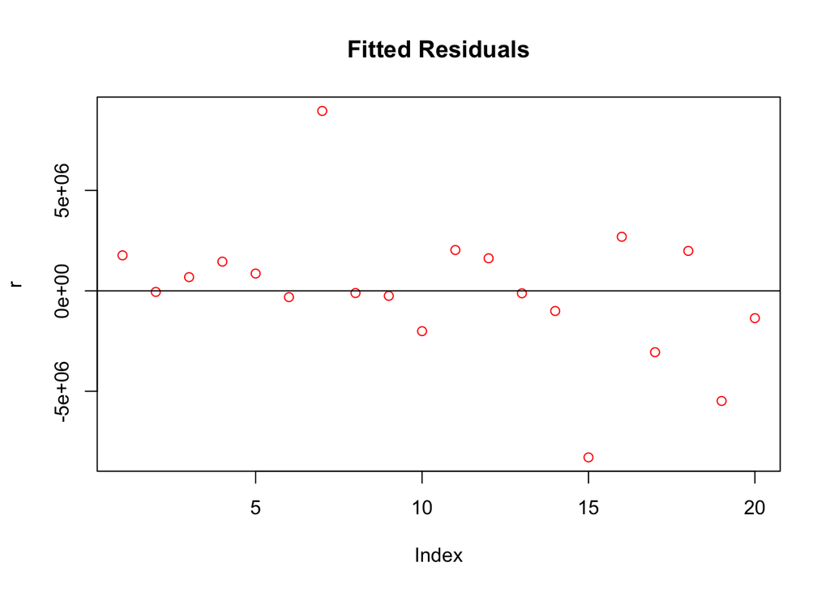

```r
plot(r,main = "Fitted Residuals", col = "red")
abline(h=0)
```

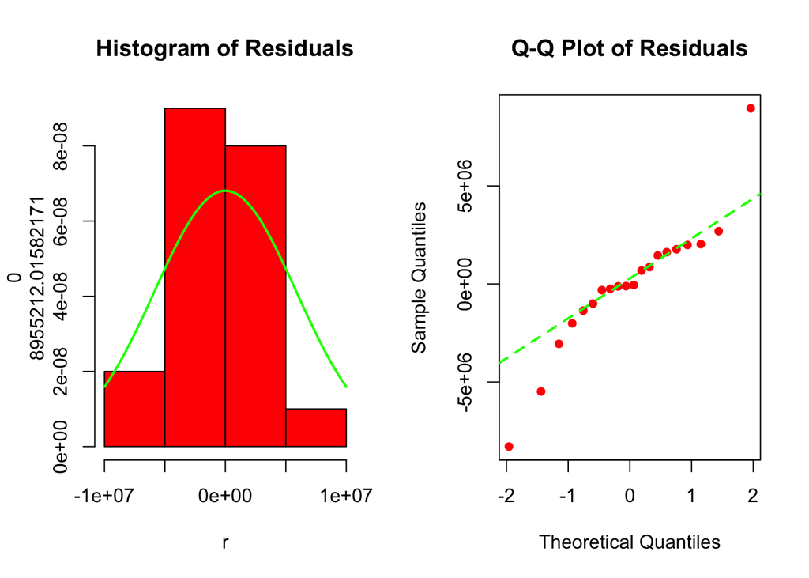

```r
fit <- fitted(rm)

library(moments)
x <- r
par(mfrow=c(1,2))
hist(r, main = "Histogram of Residuals", col = "red", freq = FALSE,ylab= c(0,max(x)))
curve(dnorm(x,0,sd(x)),add=TRUE, col="green", lwd = 2)

qqnorm(r, main = "Q-Q Plot of Residuals", col = "red", pch = 16)
qqline(r, col = "green", lty = 2, lwd = 2)
```

```r
skew = skewness(r)
kurt = kurtosis(r)
cat("Skewness of Residuals =", skew)
```

```
## Skewness of Residuals = -0.009679622
```

```r
cat("\nKurtosis of Residuals =", kurt)
```

```
##
## Kurtosis of Residuals = 5.081594
```

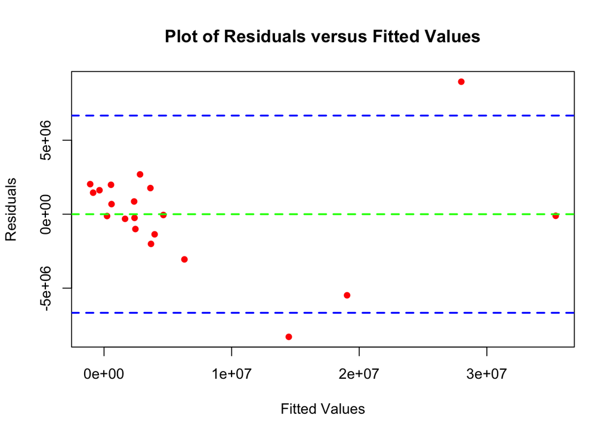

```r
par(mfrow=c(1,1))
plot(fit,r, main = "Plot of Residuals versus Fitted Values", xlab = "Fitted Values",
     ylab = "Residuals", col = "red", pch = 16)
abline(h = 0, lty = 2, lwd = 2, col = "green")
abline(h = c(1.96*sd(x), -1.96*sd(x)), lty = 2, lwd = 2, col = "blue")
```

The residual analysis reveals several aspects of the regression model’s performance. The histogram of the residuals presents a bell-shaped and symmetric distribution, suggesting a reasonable approximation to normality. This is supported by the skewness value being near zero (-0.0097), which indicates a symmetrical spread around the mean. The Q-Q plot mostly aligns with the expected diagonal line, reinforcing the notion of normality; however, deviations in the tails hint at the presence of outliers. This is further corroborated by a kurtosis value of 5.08, which points to a leptokurtic distribution—characterized by fatter tails than a normal distribution, signifying the presence of outliers. The Fitted Residuals plot does not show any systematic pattern, implying that the model’s predictive accuracy is consistent across the data range. Similarly, the Plot of Residuals versus Fitted Values suggests that the model generally fits well, with most residuals clustering around the horizontal axis, indicating homoscedasticity. Nonetheless, a few points with high residuals, especially for higher fitted values, are evident. These points may indicate potential outliers or aspects of the data variability that the model does not fully capture.

#### regression part d

The last thing we will do is use our model to predict the total new cases of two (2) countries not included in our model fit. At minimum, your work should include:

- The predicted total new cases for both countries.
- The actual total new cases for both countries.
- A short statement on the performance of the model in these two (2) cases.
  - Compare the new predictions to those made on the fitted dataset. You may compare the predicted values or the residuals.

```r
# The code below defines our 'newdata' data frame for applying our model to the
# population, population density and GDP per capita for two (2). Please execute
# the code as given.

newdata <- data.frame(country = c("Luxembourg", "Netherlands"),
                      pop = c(626108, 17407585),
                      gdp_pps = c(261, 130),
                      pop_dens = c(626108, 17407585) / c(2586, 41540))

# Add code here returning the actual  total cases from our dataset for the
# Netherlands and Luxembourg.
total_cases <- data %>%
  dplyr::select(c(countriesAndTerritories, cases)) %>%
  group_by(countriesAndTerritories) %>%
  dplyr::summarize(total_cases = sum(cases, na.rm = TRUE)) %>%
  filter(countriesAndTerritories %in% c("Luxembourg", "Netherlands")) %>%
  dplyr::select(total_cases)

newdata <- newdata %>%
  add_column(total_cases)

cat("Total Cases Luxembourg: ", newdata$total_cases[newdata$country=="Luxembourg"],
    "\nTotal Cases Netherlands:", newdata$total_cases[newdata$country=="Netherlands"])
```

```
## Total Cases Luxembourg:  301031
## Total Cases Netherlands: 8494705
```

```r
# Add code here returning the total cases for the Netherlands and Luxembourg
# predicted by our model.
myforecast <- -3.875e+06 +  4.285e-01*newdata$pop + 6.502e+02*newdata$pop_dens + 2.834e+04*newdata$gdp_pps

cat("\n\nForecasted Cases Luxembourg: ", myforecast[newdata$country=="Luxembourg"],
    "\nForecasted Cases Netherlands:", myforecast[newdata$country=="Netherlands"])
```

```
##
##
## Forecasted Cases Luxembourg:  3947450
## Forecasted Cases Netherlands: 7540820
```

```r
cat("\n\n% Diff b/w forecasted & actual Luxembourg: ", abs(newdata$total_cases[newdata$country=="Luxembourg"]-myforecast[newdata$country=="Luxembourg"])/newdata$total_cases[newdata$country=="Luxembourg"]*100,
    "%\n% Diff b/w forecasted & actual Netherlands:", abs(newdata$total_cases[newdata$country=="Netherlands"]-myforecast[newdata$country=="Netherlands"])/newdata$total_cases[newdata$country=="Netherlands"]*100,"%")
```

```
##
##
## % Diff b/w forecasted & actual Luxembourg:  1211.31 %
## % Diff b/w forecasted & actual Netherlands: 11.22917 %
```

```r
mse = mean((newdata$total_cases - myforecast)^2)
cat("\n MSE:", mse)
```

```
##
##  MSE: 7.103134e+12
```

Initial Model (multiple linear regression) Prediction:  
Luxembourg: This model highly overestimated the cases, showing a variance of over 1200% from actual cases. This indicates that the model’s assumptions or the variables used (population, GDP per capita, and population density) may not accurately capture the factors influencing COVID-19 case numbers in smaller or unique countries like Luxembourg.  
Netherlands: The model performed better for the Netherlands, with a deviation of around 11%. This suggests that these variables are more representative for larger countries with more diverse and complex socio-economic dynamics.  
MSE (Mean Squared Error): The high MSE value reflects the overall inaccuracy of the model, particularly pronounced in the case of Luxembourg.  
Overall Conclusion: While somewhat effective for larger countries, this model’s reliability diminishes significantly for smaller countries with unique characteristics.

Then, we decide to try the smaller model and compare with them.

```r
# Test the smaller model
myforecast2 <-  -9.216e+05 +  4.286e-01*newdata$pop
cat("\n\nForecasted Cases Luxembourg: ", myforecast2[newdata$country=="Luxembourg"],
    "\nForecasted Cases Netherlands:", myforecast2[newdata$country=="Netherlands"])
```

```
##
##
## Forecasted Cases Luxembourg:  -653250.1
## Forecasted Cases Netherlands: 6539291
```

```r
cat("\n\n% Diff b/w forecasted & actual Luxembourg: ", abs(newdata$total_cases[newdata$country=="Luxembourg"]-myforecast2[newdata$country=="Luxembourg"])/newdata$total_cases[newdata$country=="Luxembourg"]*100,
    "%\n% Diff b/w forecasted & actual Netherlands:", abs(newdata$total_cases[newdata$country=="Netherlands"]-myforecast2[newdata$country=="Netherlands"])/newdata$total_cases[newdata$country=="Netherlands"]*100,"%")
```

```
##
##
## % Diff b/w forecasted & actual Luxembourg:  317.0043 %
## % Diff b/w forecasted & actual Netherlands: 23.01921 %
```

```r
mse = mean((newdata$total_cases - myforecast2)^2)
cat("\n MSE:", mse)
```

```
##
##  MSE: 2.367148e+12
```

Smaller Model Predictions:  
Luxembourg: The model’s inapplicability was evident as it predicted negative cases, highlighting the limitations of using a single variable (population) for such predictions.  
Netherlands: Despite a simpler model structure, the prediction was less accurate than the initial model, with a higher deviation (23%).  
MSE: Although lower than the initial model, the errors, especially for Luxembourg, raise concerns about using overly simplified models for complex epidemiological predictions.  
Overall Conclusion: This model’s simplicity undermines its effectiveness, making it unsuitable for accurate pandemic modeling.

#### Extra Models

```r
# Generalized Linear Model (GLM): Poisson Regression
library(glmnet)
set.seed(123)
glm_model <- glm(total_cases ~ pop + gdp_pps,
                 data = model_df,
                 family = poisson())
summary(glm_model)
```

```
##
## Call:
## glm(formula = total_cases ~ pop + gdp_pps, family = poisson(),
##     data = model_df)
##
## Coefficients:
##               Estimate Std. Error z value Pr(>|z|)
## (Intercept)  1.449e+01  3.972e-04 36483.8   <2e-16 ***
## pop          3.856e-08  3.012e-12 12805.5   <2e-16 ***
## gdp_pps     -5.197e-04  3.972e-06  -130.8   <2e-16 ***
## ---
## Signif. codes:  0 '***' 0.001 '**' 0.01 '*' 0.05 '.' 0.1 ' ' 1
##
## (Dispersion parameter for poisson family taken to be 1)
##
##     Null deviance: 208152118  on 19  degrees of freedom
## Residual deviance:  21180552  on 17  degrees of freedom
## AIC: 21180891
##
## Number of Fisher Scoring iterations: 5
```

```r
predictions <- predict(glm_model, newdata = newdata, type = "response")
mse = mean((newdata$total_cases - predictions)^2)

cat("\n\nForecasted Cases Luxembourg: ", predictions[newdata$country=="Luxembourg"],
    "\nForecasted Cases Netherlands:", predictions[newdata$country=="Netherlands"])
```

```
##
##
## Forecasted Cases Luxembourg:  1757467
## Forecasted Cases Netherlands: 3593438
```

```r
cat("\n\n% Diff b/w forecasted & actual Luxembourg: ", abs(newdata$total_cases[newdata$country=="Luxembourg"]-predictions[newdata$country=="Luxembourg"])/newdata$total_cases[newdata$country=="Luxembourg"]*100,
    "%\n% Diff b/w forecasted & actual Netherlands:", abs(newdata$total_cases[newdata$country=="Netherlands"]-predictions[newdata$country=="Netherlands"])/newdata$total_cases[newdata$country=="Netherlands"]*100,"%")
```

```
##
##
## % Diff b/w forecasted & actual Luxembourg:  483.8159 %
## % Diff b/w forecasted & actual Netherlands: 57.69791 %
```

```r
cat("\n MSE:", mse)
```

```
##
##  MSE: 1.307181e+13
```

Generalized Linear Model (GLM): Poisson Regression  
Luxembourg: Despite a significant overestimation, this model provided a more realistic prediction compared to the negative values of the smaller linear model.]  
Netherlands: The model’s performance was less accurate than the initial model, indicating that a Poisson approach might not be suitable for this kind of data.  
MSE: The highest among all models, indicating poor overall predictive accuracy.  
Overall Conclusion: The GLM with a Poisson distribution shows some promise in handling smaller datasets but requires further refinement for accurate pandemic forecasting.

```r
# Random Forest model
library(randomForest)
set.seed(123)
rf_model <- randomForest(total_cases ~ pop + gdp_pps + pop_dens , data = newdata)
predictions <- predict(rf_model, newdata)
mse = mean((newdata$total_cases - predictions)^2)

cat("\n\nForecasted Cases Luxembourg: ", predictions[newdata$country=="Luxembourg"],
    "\nForecasted Cases Netherlands:", predictions[newdata$country=="Netherlands"])
```

```
##
##
## Forecasted Cases Luxembourg:  2169189
## Forecasted Cases Netherlands: 6380737
```

```r
cat("\n\n% Diff b/w forecasted & actual Luxembourg: ", abs(newdata$total_cases[newdata$country=="Luxembourg"]-predictions[newdata$country=="Luxembourg"])/newdata$total_cases[newdata$country=="Luxembourg"]*100,
    "%\n% Diff b/w forecasted & actual Netherlands:", abs(newdata$total_cases[newdata$country=="Netherlands"]-predictions[newdata$country=="Netherlands"])/newdata$total_cases[newdata$country=="Netherlands"]*100,"%")
```

```
##
##
## % Diff b/w forecasted & actual Luxembourg:  620.5865 %
## % Diff b/w forecasted & actual Netherlands: 24.88571 %
```

```r
cat("\n MSE:", mse)
```

```
##
##  MSE: 3.979437e+12
```

#### Conclusions

The initial model integrates more variables which might be capturing additional complexity in the relationship between predictors and COVID-19 case numbers in larger countries like the Netherlands. Conversely, for smaller countries like Luxembourg, the initial model’s additional complexity might be capturing noise or non-representative data, leading to a poorer prediction.

The smaller model, which only includes the population as a predictor, performs poorly for both countries but is relatively less inaccurate for Luxembourg. This may indicate that the population is a less potent predictor for smaller countries or that the model is missing other key predictive factors.

In conclusion, the varied performance of the models underscores the importance of considering country-specific characteristics when modeling epidemiological data. Smaller countries like Luxembourg may have unique factors not adequately captured by general models. The initial model seems more suited for larger countries, while the smaller model may be less prone to extreme errors for smaller countries. However, both models need refinement to improve prediction accuracy, particularly for smaller countries like Luxembourg.